# Optimal Treatment Analysis

## Outcome Variable

**Outcome Variable:** whz

## Predictor Variables

**Intervention Variable:** rain_quartile

**Adjustment Set:**

unadjusted

## Stratifying Variables

The analysis was stratified on these variable(s):

- studyid
- country
- agecat

## Data Summary

| studyid | country | agecat | rain_quartile | n_cell | n |
| --- | --- | --- | --- | --- | --- |
| CMC-V-BCS-2002 | India | Birth | 1 | 17 | 86 |
| CMC-V-BCS-2002 | India | Birth | 2 | 22 | 86 |
| CMC-V-BCS-2002 | India | Birth | 3 | 28 | 86 |
| CMC-V-BCS-2002 | India | Birth | 4 | 19 | 86 |
| CMC-V-BCS-2002 | India | 6 months | 1 | 102 | 368 |
| CMC-V-BCS-2002 | India | 6 months | 2 | 109 | 368 |
| CMC-V-BCS-2002 | India | 6 months | 3 | 97 | 368 |
| CMC-V-BCS-2002 | India | 6 months | 4 | 60 | 368 |
| CMC-V-BCS-2002 | India | 24 months | 1 | 87 | 334 |
| CMC-V-BCS-2002 | India | 24 months | 2 | 90 | 334 |
| CMC-V-BCS-2002 | India | 24 months | 3 | 95 | 334 |
| CMC-V-BCS-2002 | India | 24 months | 4 | 62 | 334 |
| CMIN | Bangladesh | Birth | 1 | 4 | 19 |
| CMIN | Bangladesh | Birth | 2 | 5 | 19 |
| CMIN | Bangladesh | Birth | 3 | 5 | 19 |
| CMIN | Bangladesh | Birth | 4 | 5 | 19 |
| CMIN | Bangladesh | 6 months | 1 | 50 | 243 |
| CMIN | Bangladesh | 6 months | 2 | 62 | 243 |
| CMIN | Bangladesh | 6 months | 3 | 70 | 243 |
| CMIN | Bangladesh | 6 months | 4 | 61 | 243 |
| CMIN | Bangladesh | 24 months | 1 | 73 | 225 |
| CMIN | Bangladesh | 24 months | 2 | 64 | 225 |
| CMIN | Bangladesh | 24 months | 3 | 52 | 225 |
| CMIN | Bangladesh | 24 months | 4 | 36 | 225 |
| CONTENT | Peru | Birth | 1 | 0 | 2 |
| CONTENT | Peru | Birth | 2 | 2 | 2 |
| CONTENT | Peru | Birth | 3 | 0 | 2 |
| CONTENT | Peru | Birth | 4 | 0 | 2 |
| CONTENT | Peru | 6 months | 1 | 62 | 215 |
| CONTENT | Peru | 6 months | 2 | 32 | 215 |

[output cut: 238 more lines]

The following strata were considered:

- studyid: CMC-V-BCS-2002, country: India, agecat: 24 months
- studyid: CMC-V-BCS-2002, country: India, agecat: 6 months
- studyid: CMC-V-BCS-2002, country: India, agecat: Birth
- studyid: CMIN, country: Bangladesh, agecat: 24 months
- studyid: CMIN, country: Bangladesh, agecat: 6 months
- studyid: CMIN, country: Bangladesh, agecat: Birth
- studyid: CONTENT, country: Peru, agecat: 24 months
- studyid: CONTENT, country: Peru, agecat: 6 months
- studyid: CONTENT, country: Peru, agecat: Birth
- studyid: EE, country: Pakistan, agecat: 24 months
- studyid: EE, country: Pakistan, agecat: 6 months
- studyid: EE, country: Pakistan, agecat: Birth
- studyid: GMS-Nepal, country: Nepal, agecat: 24 months
- studyid: GMS-Nepal, country: Nepal, agecat: 6 months
- studyid: GMS-Nepal, country: Nepal, agecat: Birth
- studyid: Guatemala BSC, country: Guatemala, agecat: 6 months
- studyid: IRC, country: India, agecat: 24 months
- studyid: IRC, country: India, agecat: 6 months
- studyid: IRC, country: India, agecat: Birth
- studyid: JiVitA-3, country: Bangladesh, agecat: 24 months
- studyid: JiVitA-3, country: Bangladesh, agecat: 6 months
- studyid: JiVitA-3, country: Bangladesh, agecat: Birth
- studyid: JiVitA-4, country: Bangladesh, agecat: 24 months
- studyid: JiVitA-4, country: Bangladesh, agecat: 6 months
- studyid: JiVitA-4, country: Bangladesh, agecat: Birth
- studyid: Keneba, country: Gambia, agecat: 24 months
- studyid: Keneba, country: Gambia, agecat: 6 months
- studyid: Keneba, country: Gambia, agecat: Birth
- studyid: LCNI-5, country: Malawi, agecat: 24 months
- studyid: LCNI-5, country: Malawi, agecat: 6 months
- studyid: MAL-ED, country: Bangladesh, agecat: 24 months
- studyid: MAL-ED, country: Bangladesh, agecat: 6 months
- studyid: MAL-ED, country: Bangladesh, agecat: Birth
- studyid: MAL-ED, country: Brazil, agecat: 24 months
- studyid: MAL-ED, country: Brazil, agecat: 6 months
- studyid: MAL-ED, country: Brazil, agecat: Birth
- studyid: MAL-ED, country: India, agecat: 24 months
- studyid: MAL-ED, country: India, agecat: 6 months
- studyid: MAL-ED, country: India, agecat: Birth
- studyid: MAL-ED, country: Nepal, agecat: 24 months
- studyid: MAL-ED, country: Nepal, agecat: 6 months
- studyid: MAL-ED, country: Nepal, agecat: Birth
- studyid: MAL-ED, country: Peru, agecat: 24 months
- studyid: MAL-ED, country: Peru, agecat: 6 months
- studyid: MAL-ED, country: Peru, agecat: Birth
- studyid: MAL-ED, country: South Africa, agecat: 24 months
- studyid: MAL-ED, country: South Africa, agecat: 6 months
- studyid: MAL-ED, country: South Africa, agecat: Birth
- studyid: MAL-ED, country: Tanzania, agecat: 24 months
- studyid: MAL-ED, country: Tanzania, agecat: 6 months
- studyid: MAL-ED, country: Tanzania, agecat: Birth
- studyid: PROBIT, country: Belarus, agecat: 24 months
- studyid: PROBIT, country: Belarus, agecat: 6 months
- studyid: PROBIT, country: Belarus, agecat: Birth
- studyid: PROVIDE, country: Bangladesh, agecat: 24 months
- studyid: PROVIDE, country: Bangladesh, agecat: 6 months
- studyid: PROVIDE, country: Bangladesh, agecat: Birth
- studyid: ResPak, country: Pakistan, agecat: 6 months
- studyid: ResPak, country: Pakistan, agecat: Birth
- studyid: SAS-CompFeed, country: India, agecat: 6 months
- studyid: SAS-CompFeed, country: India, agecat: Birth
- studyid: SAS-FoodSuppl, country: India, agecat: 6 months
- studyid: TanzaniaChild2, country: Tanzania, agecat: 24 months
- studyid: TanzaniaChild2, country: Tanzania, agecat: 6 months
- studyid: ZVITAMBO, country: Zimbabwe, agecat: 24 months
- studyid: ZVITAMBO, country: Zimbabwe, agecat: 6 months
- studyid: ZVITAMBO, country: Zimbabwe, agecat: Birth

### Dropped Strata

Some strata were dropped due to rare outcomes:

- studyid: CMIN, country: Bangladesh, agecat: Birth
- studyid: CONTENT, country: Peru, agecat: Birth
- studyid: EE, country: Pakistan, agecat: Birth
- studyid: EE, country: Pakistan, agecat: 6 months
- studyid: EE, country: Pakistan, agecat: 24 months
- studyid: GMS-Nepal, country: Nepal, agecat: Birth
- studyid: GMS-Nepal, country: Nepal, agecat: 6 months
- studyid: GMS-Nepal, country: Nepal, agecat: 24 months
- studyid: JiVitA-3, country: Bangladesh, agecat: 24 months
- studyid: PROVIDE, country: Bangladesh, agecat: 24 months
- studyid: ResPak, country: Pakistan, agecat: Birth
- studyid: TanzaniaChild2, country: Tanzania, agecat: 24 months

## Methods Detail

We’re interested in the causal parameters $E[Y_a]$ for all values of $a \in \mathcal{A}$. These parameters represent the mean outcome if, possibly contrary to fact, we intervened to set all units to have $A=a$. Under the randomization and positivity assumptions, these are identified by the statistical parameters $\psi_a=E_W[E_{Y|A,W}(Y|A=a,W)]$. In addition, we’re interested in the mean of $Y$, $E[Y]$ under no intervention (the observed mean). We will estimate these parameters by using SuperLearner to fit the relevant likelihood factors – $E_{Y|A,W}(Y|A=a,W)$ and $p(A=a|W)$, and then updating our likelihood fit using a joint TMLE.

For unadjusted analyses ($W=\{\}$), initial likelihoods were estimated using Lrnr_glm to estimate the simple $E(Y|A)$ and Lrnr_mean to estimate $p(A)$. For adjusted analyses, a small library containing Lrnr_glmnet, Lrnr_xgboost, and Lrnr_mean was used.

Having estimated these parameters, we will then use the delta method to estimate relative risks and attributable risks relative to a prespecified baseline level of $A$.

# Results Detail

## Results Plots

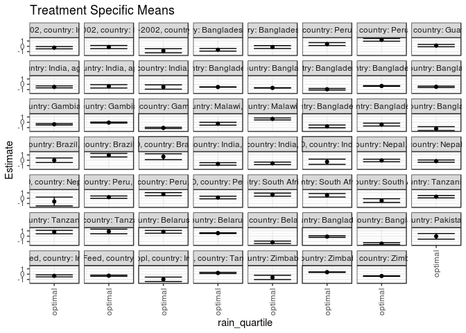

## Results Table

### Parameter: TSM

| studyid | country | agecat | intervention_level | baseline_level | estimate | ci_lower | ci_upper |
| --- | --- | --- | --- | --- | --- | --- | --- |
| CMC-V-BCS-2002 | India | Birth | optimal | observed | -0.8365946 | -1.2244348 | -0.4487545 |
| CMC-V-BCS-2002 | India | 6 months | optimal | observed | -0.1440150 | -0.4373829 | 0.1493528 |
| CMC-V-BCS-2002 | India | 24 months | optimal | observed | -0.2597339 | -0.4752318 | -0.0442360 |
| CMIN | Bangladesh | 6 months | optimal | observed | -0.1402653 | -0.4128800 | 0.1323494 |
| CMIN | Bangladesh | 24 months | optimal | observed | -0.6542243 | -0.8988992 | -0.4095494 |
| CONTENT | Peru | 6 months | optimal | observed | 1.2147036 | 0.9555826 | 1.4738246 |
| CONTENT | Peru | 24 months | optimal | observed | 0.4206450 | 0.1460761 | 0.6952138 |
| Guatemala BSC | Guatemala | 6 months | optimal | observed | 0.1301427 | -0.0871896 | 0.3474750 |
| IRC | India | Birth | optimal | observed | -0.5123583 | -0.9136076 | -0.1111091 |
| IRC | India | 6 months | optimal | observed | -0.3869618 | -0.7056987 | -0.0682249 |
| IRC | India | 24 months | optimal | observed | -0.4923731 | -0.6760472 | -0.3086990 |
| JiVitA-3 | Bangladesh | Birth | optimal | observed | -0.6782230 | -0.7117684 | -0.6446776 |
| JiVitA-3 | Bangladesh | 6 months | optimal | observed | -0.5158963 | -0.5554217 | -0.4763709 |
| JiVitA-4 | Bangladesh | Birth | optimal | observed | -0.4744799 | -0.6067813 | -0.3421785 |
| JiVitA-4 | Bangladesh | 6 months | optimal | observed | -0.3228283 | -0.3863468 | -0.2593098 |
| JiVitA-4 | Bangladesh | 24 months | optimal | observed | -0.9431136 | -1.0984420 | -0.7877853 |
| Keneba | Gambia | Birth | optimal | observed | -1.0647833 | -1.1866986 | -0.9428679 |
| Keneba | Gambia | 6 months | optimal | observed | -0.0648244 | -0.1584350 | 0.0287861 |
| Keneba | Gambia | 24 months | optimal | observed | -0.3812121 | -0.5197979 | -0.2426263 |
| LCNI-5 | Malawi | 6 months | optimal | observed | 0.6251746 | 0.4400776 | 0.8102717 |
| LCNI-5 | Malawi | 24 months | optimal | observed | -0.2757146 | -0.5443506 | -0.0070787 |
| MAL-ED | Bangladesh | Birth | optimal | observed | -1.1914790 | -1.5523917 | -0.8305664 |
| MAL-ED | Bangladesh | 6 months | optimal | observed | -0.4365798 | -0.7056010 | -0.1675586 |
| MAL-ED | Bangladesh | 24 months | optimal | observed | -0.7852312 | -1.0492281 | -0.5212344 |
| MAL-ED | Brazil | Birth | optimal | observed | 0.6619264 | 0.1075315 | 1.2163214 |
| MAL-ED | Brazil | 6 months | optimal | observed | 0.9474713 | 0.6151938 | 1.2797488 |
| MAL-ED | Brazil | 24 months | optimal | observed | 0.0007329 | -0.4260492 | 0.4275149 |
| MAL-ED | India | Birth | optimal | observed | -0.2878025 | -0.7791681 | 0.2035631 |
| MAL-ED | India | 6 months | optimal | observed | -0.5893528 | -0.8277857 | -0.3509199 |
| MAL-ED | India | 24 months | optimal | observed | -0.6962896 | -0.9337893 | -0.4587898 |
| MAL-ED | Nepal | Birth | optimal | observed | -0.6182399 | -1.4487844 | 0.2123047 |
| MAL-ED | Nepal | 6 months | optimal | observed | -0.1650896 | -0.3794117 | 0.0492325 |
| MAL-ED | Nepal | 24 months | optimal | observed | -0.0456653 | -0.2804857 | 0.1891550 |
| MAL-ED | Peru | Birth | optimal | observed | 0.1285124 | -0.1200247 | 0.3770494 |
| MAL-ED | Peru | 6 months | optimal | observed | 0.7595153 | 0.4703432 | 1.0486875 |
| MAL-ED | Peru | 24 months | optimal | observed | 0.1933229 | -0.0311616 | 0.4178074 |
| MAL-ED | South Africa | Birth | optimal | observed | -0.4517024 | -0.7971814 | -0.1062234 |
| MAL-ED | South Africa | 6 months | optimal | observed | 0.5479135 | 0.2155012 | 0.8803257 |
| MAL-ED | South Africa | 24 months | optimal | observed | 0.6684355 | 0.3743190 | 0.9625520 |
| MAL-ED | Tanzania | Birth | optimal | observed | 0.8868979 | 0.4584735 | 1.3153223 |
| MAL-ED | Tanzania | 6 months | optimal | observed | 0.7813219 | 0.4508041 | 1.1118397 |
| MAL-ED | Tanzania | 24 months | optimal | observed | 0.2835163 | 0.0583030 | 0.5087296 |
| PROBIT | Belarus | Birth | optimal | observed | -1.1542847 | -1.3852975 | -0.9232719 |
| PROBIT | Belarus | 6 months | optimal | observed | 0.5717131 | 0.5023302 | 0.6410960 |
| PROBIT | Belarus | 24 months | optimal | observed | 0.8233335 | 0.5561717 | 1.0904954 |
| PROVIDE | Bangladesh | Birth | optimal | observed | -1.4020580 | -1.5830350 | -1.2210810 |
| PROVIDE | Bangladesh | 6 months | optimal | observed | -0.0729466 | -0.2296453 | 0.0837521 |
| ResPak | Pakistan | 6 months | optimal | observed | -0.0309652 | -0.5582166 | 0.4962863 |
| SAS-CompFeed | India | Birth | optimal | observed | -0.2940026 | -0.4025280 | -0.1854773 |
| SAS-CompFeed | India | 6 months | optimal | observed | -0.3218190 | -0.5152154 | -0.1284226 |
| SAS-FoodSuppl | India | 6 months | optimal | observed | -0.9713693 | -1.3844212 | -0.5583175 |
| TanzaniaChild2 | Tanzania | 6 months | optimal | observed | 0.2279984 | 0.1194478 | 0.3365491 |
| ZVITAMBO | Zimbabwe | Birth | optimal | observed | -0.3544695 | -0.4063555 | -0.3025835 |
| ZVITAMBO | Zimbabwe | 6 months | optimal | observed | 0.3757791 | 0.3229236 | 0.4286345 |
| ZVITAMBO | Zimbabwe | 24 months | optimal | observed | -0.6112217 | -1.0197218 | -0.2027217 |

### Parameter: E(Y)

| studyid | country | agecat | intervention_level | baseline_level | estimate | ci_lower | ci_upper |
| --- | --- | --- | --- | --- | --- | --- | --- |
| CMC-V-BCS-2002 | India | Birth | observed | observed | -0.4648256 | -0.7643210 | -0.1653302 |
| CMC-V-BCS-2002 | India | 6 months | observed | observed | -0.5026766 | -0.6536848 | -0.3516685 |
| CMC-V-BCS-2002 | India | 24 months | observed | observed | -0.4918563 | -0.5993711 | -0.3843415 |
| CMIN | Bangladesh | 6 months | observed | observed | -0.5780453 | -0.7226627 | -0.4334279 |
| CMIN | Bangladesh | 24 months | observed | observed | -0.8828667 | -0.9954180 | -0.7703153 |
| CONTENT | Peru | 6 months | observed | observed | 1.0684318 | 0.9515274 | 1.1853362 |
| CONTENT | Peru | 24 months | observed | observed | 0.5668293 | 0.4302437 | 0.7034148 |
| Guatemala BSC | Guatemala | 6 months | observed | observed | -0.0840134 | -0.1945572 | 0.0265305 |
| IRC | India | Birth | observed | observed | -1.0105831 | -1.1973019 | -0.8238643 |
| IRC | India | 6 months | observed | observed | -0.5989297 | -0.7344491 | -0.4634104 |
| IRC | India | 24 months | observed | observed | -0.6724063 | -0.7718177 | -0.5729950 |
| JiVitA-3 | Bangladesh | Birth | observed | observed | -0.7775928 | -0.7966054 | -0.7585803 |
| JiVitA-3 | Bangladesh | 6 months | observed | observed | -0.5935161 | -0.6130518 | -0.5739805 |
| JiVitA-4 | Bangladesh | Birth | observed | observed | -0.6886269 | -0.7410452 | -0.6362086 |
| JiVitA-4 | Bangladesh | 6 months | observed | observed | -0.3898055 | -0.4270507 | -0.3525603 |
| JiVitA-4 | Bangladesh | 24 months | observed | observed | -1.1425394 | -1.2092463 | -1.0758325 |
| Keneba | Gambia | Birth | observed | observed | -1.2349454 | -1.2972413 | -1.1726496 |
| Keneba | Gambia | 6 months | observed | observed | -0.1846038 | -0.2354782 | -0.1337293 |
| Keneba | Gambia | 24 months | observed | observed | -0.6709076 | -0.7479171 | -0.5938981 |
| LCNI-5 | Malawi | 6 months | observed | observed | 0.4499404 | 0.3788501 | 0.5210308 |
| LCNI-5 | Malawi | 24 months | observed | observed | 0.0097837 | -0.1272983 | 0.1468656 |
| MAL-ED | Bangladesh | Birth | observed | observed | -0.9418605 | -1.0869834 | -0.7967375 |
| MAL-ED | Bangladesh | 6 months | observed | observed | -0.1376763 | -0.2664642 | -0.0088885 |
| MAL-ED | Bangladesh | 24 months | observed | observed | -0.7678075 | -0.8977960 | -0.6378190 |
| MAL-ED | Brazil | Birth | observed | observed | 0.4029032 | 0.0896793 | 0.7161272 |
| MAL-ED | Brazil | 6 months | observed | observed | 0.9720774 | 0.8078144 | 1.1363403 |
| MAL-ED | Brazil | 24 months | observed | observed | 0.5807485 | 0.3680997 | 0.7933973 |
| MAL-ED | India | Birth | observed | observed | -0.9324444 | -1.2067907 | -0.6580982 |
| MAL-ED | India | 6 months | observed | observed | -0.7047422 | -0.8301590 | -0.5793255 |
| MAL-ED | India | 24 months | observed | observed | -0.8847525 | -1.0071803 | -0.7623246 |
| MAL-ED | Nepal | Birth | observed | observed | -0.7684615 | -1.1257770 | -0.4111460 |
| MAL-ED | Nepal | 6 months | observed | observed | 0.1104308 | -0.0208643 | 0.2417259 |
| MAL-ED | Nepal | 24 months | observed | observed | -0.2779250 | -0.3991916 | -0.1566584 |
| MAL-ED | Peru | Birth | observed | observed | -0.0520175 | -0.1725298 | 0.0684947 |
| MAL-ED | Peru | 6 months | observed | observed | 1.0528816 | 0.9313005 | 1.1744626 |
| MAL-ED | Peru | 24 months | observed | observed | 0.1542462 | 0.0295657 | 0.2789268 |
| MAL-ED | South Africa | Birth | observed | observed | -0.1925833 | -0.4053570 | 0.0201904 |
| MAL-ED | South Africa | 6 months | observed | observed | 0.5421785 | 0.3900443 | 0.6943126 |
| MAL-ED | South Africa | 24 months | observed | observed | 0.4185314 | 0.2754687 | 0.5615940 |
| MAL-ED | Tanzania | Birth | observed | observed | 0.7624348 | 0.5710709 | 0.9537986 |
| MAL-ED | Tanzania | 6 months | observed | observed | 0.5362213 | 0.4049390 | 0.6675036 |
| MAL-ED | Tanzania | 24 months | observed | observed | 0.1195993 | -0.0198585 | 0.2590571 |
| PROBIT | Belarus | Birth | observed | observed | -1.1448633 | -1.3544229 | -0.9353037 |
| PROBIT | Belarus | 6 months | observed | observed | 0.5789633 | 0.5190130 | 0.6389137 |
| PROBIT | Belarus | 24 months | observed | observed | 0.8158885 | 0.6420546 | 0.9897224 |
| PROVIDE | Bangladesh | Birth | observed | observed | -1.2984586 | -1.3752758 | -1.2216415 |
| PROVIDE | Bangladesh | 6 months | observed | observed | -0.1990907 | -0.2817968 | -0.1163845 |
| ResPak | Pakistan | 6 months | observed | observed | -0.1641841 | -0.3464247 | 0.0180565 |
| SAS-CompFeed | India | Birth | observed | observed | -0.6700453 | -0.8474950 | -0.4925957 |
| SAS-CompFeed | India | 6 months | observed | observed | -0.6657084 | -0.8024377 | -0.5289791 |
| SAS-FoodSuppl | India | 6 months | observed | observed | -1.0121579 | -1.1280429 | -0.8962729 |
| TanzaniaChild2 | Tanzania | 6 months | observed | observed | 0.0809332 | 0.0282644 | 0.1336020 |
| ZVITAMBO | Zimbabwe | Birth | observed | observed | -0.5151425 | -0.5409938 | -0.4892911 |
| ZVITAMBO | Zimbabwe | 6 months | observed | observed | 0.3105514 | 0.2848767 | 0.3362262 |
| ZVITAMBO | Zimbabwe | 24 months | observed | observed | -1.0542222 | -1.2909384 | -0.8175060 |

### Parameter: PAR

| studyid | country | agecat | intervention_level | baseline_level | estimate | ci_lower | ci_upper |
| --- | --- | --- | --- | --- | --- | --- | --- |
| CMC-V-BCS-2002 | India | Birth | optimal | observed | 0.3717690 | -0.0395202 | 0.7830583 |
| CMC-V-BCS-2002 | India | 6 months | optimal | observed | -0.3586616 | -0.6074087 | -0.1099146 |
| CMC-V-BCS-2002 | India | 24 months | optimal | observed | -0.2321224 | -0.4172062 | -0.0470386 |
| CMIN | Bangladesh | 6 months | optimal | observed | -0.4377800 | -0.6938739 | -0.1816861 |
| CMIN | Bangladesh | 24 months | optimal | observed | -0.2286424 | -0.4413428 | -0.0159419 |
| CONTENT | Peru | 6 months | optimal | observed | -0.1462718 | -0.3793777 | 0.0868340 |
| CONTENT | Peru | 24 months | optimal | observed | 0.1461843 | -0.0990038 | 0.3913724 |
| Guatemala BSC | Guatemala | 6 months | optimal | observed | -0.2141561 | -0.3998826 | -0.0284295 |
| IRC | India | Birth | optimal | observed | -0.4982247 | -0.8502410 | -0.1462085 |
| IRC | India | 6 months | optimal | observed | -0.2119679 | -0.4997269 | 0.0757910 |
| IRC | India | 24 months | optimal | observed | -0.1800332 | -0.3438621 | -0.0162044 |
| JiVitA-3 | Bangladesh | Birth | optimal | observed | -0.0993699 | -0.1251326 | -0.0736072 |
| JiVitA-3 | Bangladesh | 6 months | optimal | observed | -0.0776198 | -0.1124414 | -0.0427982 |
| JiVitA-4 | Bangladesh | Birth | optimal | observed | -0.2141470 | -0.3398877 | -0.0884063 |
| JiVitA-4 | Bangladesh | 6 months | optimal | observed | -0.0669772 | -0.1188421 | -0.0151123 |
| JiVitA-4 | Bangladesh | 24 months | optimal | observed | -0.1994258 | -0.3462227 | -0.0526289 |
| Keneba | Gambia | Birth | optimal | observed | -0.1701622 | -0.2769505 | -0.0633738 |
| Keneba | Gambia | 6 months | optimal | observed | -0.1197793 | -0.1989614 | -0.0405972 |
| Keneba | Gambia | 24 months | optimal | observed | -0.2896955 | -0.4145157 | -0.1648752 |
| LCNI-5 | Malawi | 6 months | optimal | observed | -0.1752342 | -0.3489327 | -0.0015357 |
| LCNI-5 | Malawi | 24 months | optimal | observed | 0.2854983 | 0.0198922 | 0.5511044 |
| MAL-ED | Bangladesh | Birth | optimal | observed | 0.2496186 | -0.0622943 | 0.5615314 |
| MAL-ED | Bangladesh | 6 months | optimal | observed | 0.2989034 | 0.0612146 | 0.5365923 |
| MAL-ED | Bangladesh | 24 months | optimal | observed | 0.0174237 | -0.2078871 | 0.2427346 |
| MAL-ED | Brazil | Birth | optimal | observed | -0.2590232 | -0.7546678 | 0.2366214 |
| MAL-ED | Brazil | 6 months | optimal | observed | 0.0246060 | -0.2747225 | 0.3239346 |
| MAL-ED | Brazil | 24 months | optimal | observed | 0.5800156 | 0.2010053 | 0.9590259 |
| MAL-ED | India | Birth | optimal | observed | -0.6446420 | -1.0631150 | -0.2261689 |
| MAL-ED | India | 6 months | optimal | observed | -0.1153894 | -0.3189638 | 0.0881849 |
| MAL-ED | India | 24 months | optimal | observed | -0.1884629 | -0.3989860 | 0.0220602 |
| MAL-ED | Nepal | Birth | optimal | observed | -0.1502217 | -0.9080454 | 0.6076021 |
| MAL-ED | Nepal | 6 months | optimal | observed | 0.2755204 | 0.0736036 | 0.4774371 |
| MAL-ED | Nepal | 24 months | optimal | observed | -0.2322597 | -0.4391384 | -0.0253809 |
| MAL-ED | Peru | Birth | optimal | observed | -0.1805299 | -0.4026167 | 0.0415569 |
| MAL-ED | Peru | 6 months | optimal | observed | 0.2933662 | 0.0339768 | 0.5527557 |
| MAL-ED | Peru | 24 months | optimal | observed | -0.0390767 | -0.2393303 | 0.1611769 |
| MAL-ED | South Africa | Birth | optimal | observed | 0.2591191 | -0.0765277 | 0.5947659 |
| MAL-ED | South Africa | 6 months | optimal | observed | -0.0057350 | -0.3197374 | 0.3082674 |
| MAL-ED | South Africa | 24 months | optimal | observed | -0.2499042 | -0.5144525 | 0.0146441 |
| MAL-ED | Tanzania | Birth | optimal | observed | -0.1244631 | -0.5451866 | 0.2962604 |
| MAL-ED | Tanzania | 6 months | optimal | observed | -0.2451006 | -0.5444962 | 0.0542951 |
| MAL-ED | Tanzania | 24 months | optimal | observed | -0.1639170 | -0.3715342 | 0.0437002 |
| PROBIT | Belarus | Birth | optimal | observed | 0.0094214 | -0.0686822 | 0.0875250 |
| PROBIT | Belarus | 6 months | optimal | observed | 0.0072502 | -0.0346650 | 0.0491655 |
| PROBIT | Belarus | 24 months | optimal | observed | -0.0074450 | -0.1927631 | 0.1778730 |
| PROVIDE | Bangladesh | Birth | optimal | observed | 0.1035994 | -0.0574404 | 0.2646391 |
| PROVIDE | Bangladesh | 6 months | optimal | observed | -0.1261441 | -0.2590486 | 0.0067604 |
| ResPak | Pakistan | 6 months | optimal | observed | -0.1332189 | -0.6369597 | 0.3705219 |
| SAS-CompFeed | India | Birth | optimal | observed | -0.3760427 | -0.4841987 | -0.2678867 |
| SAS-CompFeed | India | 6 months | optimal | observed | -0.3438894 | -0.4262372 | -0.2615416 |
| SAS-FoodSuppl | India | 6 months | optimal | observed | -0.0407886 | -0.4278262 | 0.3462490 |
| TanzaniaChild2 | Tanzania | 6 months | optimal | observed | -0.1470653 | -0.2426629 | -0.0514676 |
| ZVITAMBO | Zimbabwe | Birth | optimal | observed | -0.1606729 | -0.2054821 | -0.1158638 |
| ZVITAMBO | Zimbabwe | 6 months | optimal | observed | -0.0652277 | -0.1105993 | -0.0198560 |
| ZVITAMBO | Zimbabwe | 24 months | optimal | observed | -0.4430005 | -0.8283060 | -0.0576950 |